# Machine Learning Course Project

Matt Frichtl

September 16, 2015

```r
set.seed(12345)
library(dplyr)
```

```r
library(ggplot2)
library(caret)
```

# Introduction

This dataset was collected by attaching sensors to subjects and having them perform various exercises. Some of the subjects performed these exercises incorrectly while others did not, indicated by the “classe” variable in the training dataset. The goal of this assignment is to predict the “classe” of each subject in the testing dataset by building a machine learning algorithm from the training set.

This was accomplished by processing the training set to remove unnecessary, near-zero variance, and highly correlated variables. A predictive model was then built using a random forest algorithm with k-fold cross-validation. This model was applied to the test set to predict what the classe of each subect in the test set is.

# Data Processing

First the data was read in and the first 7 variables were dropped as they were not related to the method that each exercise was performed. Then variables that contained ~90% NAs and were near-zero variance were also removed.

```r
testing <- data.frame(read.csv(file = "./pml-testing.csv"))
training <- data.frame(read.csv(file = "./pml-training.csv", header = TRUE)) %>%
  select(-matches("X"),
         -matches("user_name"),
         -starts_with("raw_timestamp_part_"),
         -matches("cvtd_timestamp"),
         -ends_with("_window"))

training <- training[, colSums(is.na(training)) < 0.9 * nrow(training)]

nzv <- nearZeroVar(x = training,
                   saveMetrics = TRUE,
                   allowParallel = TRUE)

training <- training %>%
  select(-one_of(rownames(nzv)[nzv$nzv == TRUE]))
```

Next, the highly correlated variables were identified and one of each pair was removed from the data set.

```r
training_classe <- training %>%
  select(-matches("classe"))

cor_mat <- findCorrelation(cor(training_classe), verbose = TRUE, names = TRUE)
```

```
## Compare row 8  and column  7 with corr  0.933
##   Means:  0.285 vs 0.164 so flagging column 8
## Compare row 7  and column  1 with corr  0.925
##   Means:  0.261 vs 0.158 so flagging column 7
## Compare row 1  and column  4 with corr  0.981
##   Means:  0.241 vs 0.153 so flagging column 1
## Compare row 36  and column  26 with corr  0.933
##   Means:  0.092 vs 0.153 so flagging column 26
## All correlations <= 0.9
```

```r
training <- training %>%
  select(-one_of(cor_mat))
```

Next the model was built. For this assignment, a random forest algorith was selected in order to classify the test set. Principle component analysis was used as a pre-processing technique and k-fold cross-validation was used to increase the accuracy of the model. The cross-validation selected used 10 folds and was repeated 3 times.

```r
control <- trainControl(method = "repeatedcv", number = 10, repeats = 3)

modelFit <- train(training$classe ~ .,
                  preProcess = "pca",
                  method = "rf",
                  trControl = control,
                  data = training,
                  allowParallel = TRUE)
finalModel <- modelFit$finalModel
modelFit
```

```
## Random Forest
##
## 19622 samples
##    36 predictors
##     5 classes: 'A', 'B', 'C', 'D', 'E'
##
## Pre-processing: principal component signal extraction, scaled, centered
## Resampling: Cross-Validated (10 fold, repeated 3 times)
## Summary of sample sizes: 17660, 17659, 17659, 17662, 17659, 17660, ...
## Resampling results across tuning parameters:
##
##   mtry  Accuracy   Kappa      Accuracy SD  Kappa SD
##    2    0.9811267  0.9761218  0.002723452  0.003447025
##   19    0.9736694  0.9666920  0.003546689  0.004484456
##   36    0.9703737  0.9625240  0.003899110  0.004928794
##
## Accuracy was used to select the optimal model using  the largest value.
## The final value used for the model was mtry = 2.
```

```r
finalModel
```

```
##
## Call:
##  randomForest(x = x, y = y, mtry = param$mtry, allowParallel = TRUE)
##                Type of random forest: classification
##                      Number of trees: 500
## No. of variables tried at each split: 2
##
##         OOB estimate of  error rate: 1.73%
## Confusion matrix:
##      A    B    C    D    E class.error
## A 5557    5   11    5    2 0.004121864
## B   50 3702   40    2    3 0.025019752
## C    7   33 3349   29    4 0.021332554
## D    1    1   96 3112    6 0.032338308
## E    0    9   25   11 3562 0.012475742
```

Next the prediction was graphed to show the classe for each observation “X”" in the test set.

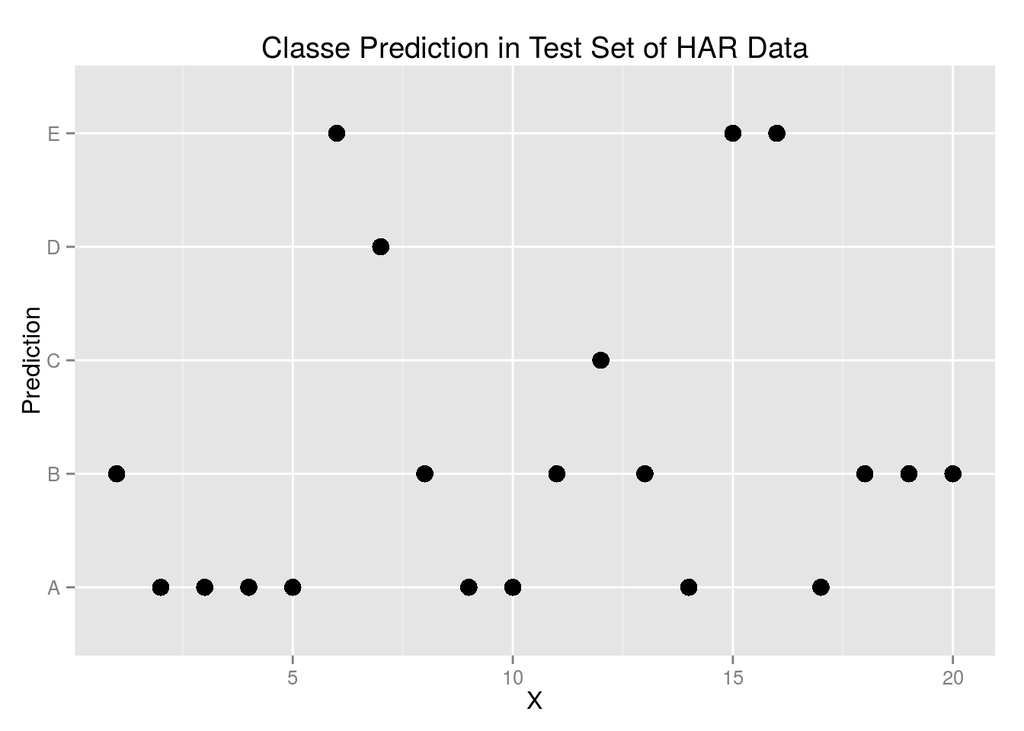

```r
pred <- predict(modelFit, newdata = testing)
ggplot(data = testing, aes(x = X, y = pred)) +
  geom_point(size = 4) +
  labs(x = "X",
       y = "Prediction",
       title ="Classe Prediction in Test Set of HAR Data")
```

The graph above shows the predicted classe for each observation in the test set. It was generated using the prediction model created for this assignment.